# TUTORIAL EXERCISES @ http://r4ds.had.co.nz/data-visualisation.html

# Continous Variables

- displ
- hwy
- year
- cty

3)Map a continuous variable to color, size, and shape. How do these aesthetics behave differently for categorical vs. continuous variables?

## COLOR

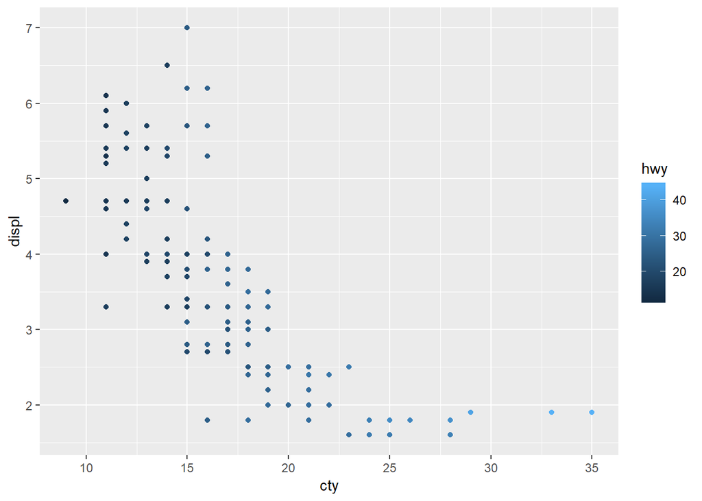

```r
ggplot(mpg,aes(x=cty,y=displ,color=hwy))+geom_point()
```

## SIZE

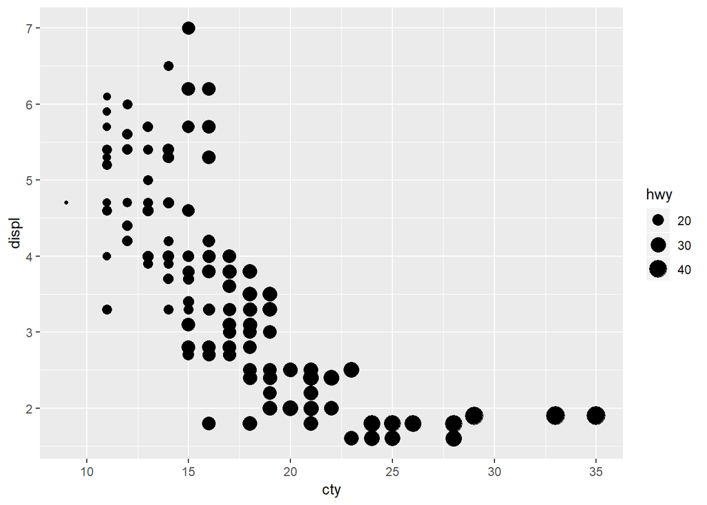

```r
ggplot(mpg,aes(x=cty,y=displ,size=hwy))+geom_point()
```

## SHAPE

```r
#ggplot(mpg,aes(x=cty,y=displ,shape=year))+geom_point()
```

Continous variable cannot be mapped to shape

## Color with categorical variable

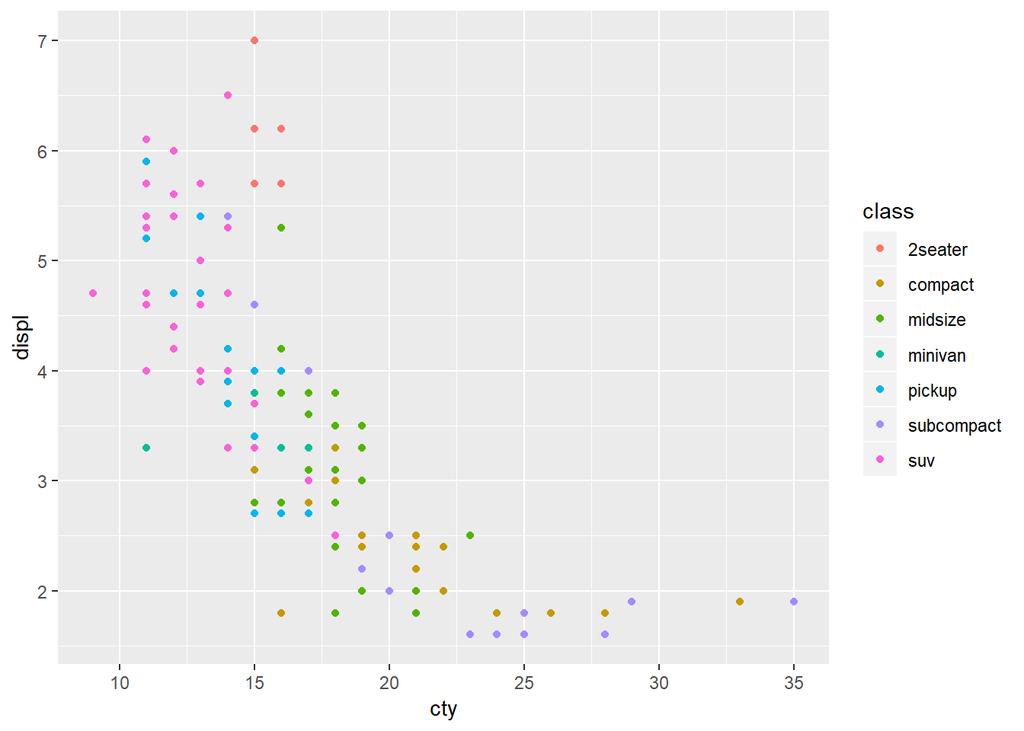

```r
ggplot(mpg,aes(x=cty,y=displ,color=class))+geom_point()
```

Ans :For continous variable there was same colour with different intensity , while for categorical variables there are different colours for each type.

## Size with categorical variable

```
## Warning: Using size for a discrete variable is not advised.
```

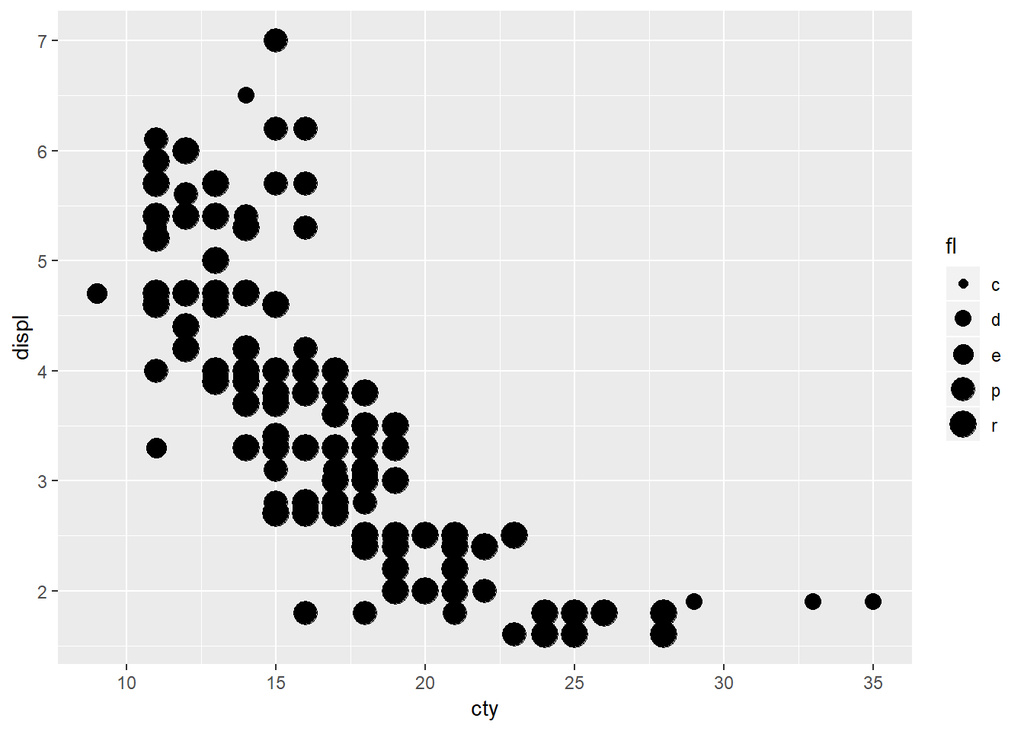

```r
ggplot(mpg,aes(x=cty,y=displ,size=fl))+geom_point()
```

A warning with size is not advised for discrete variables.

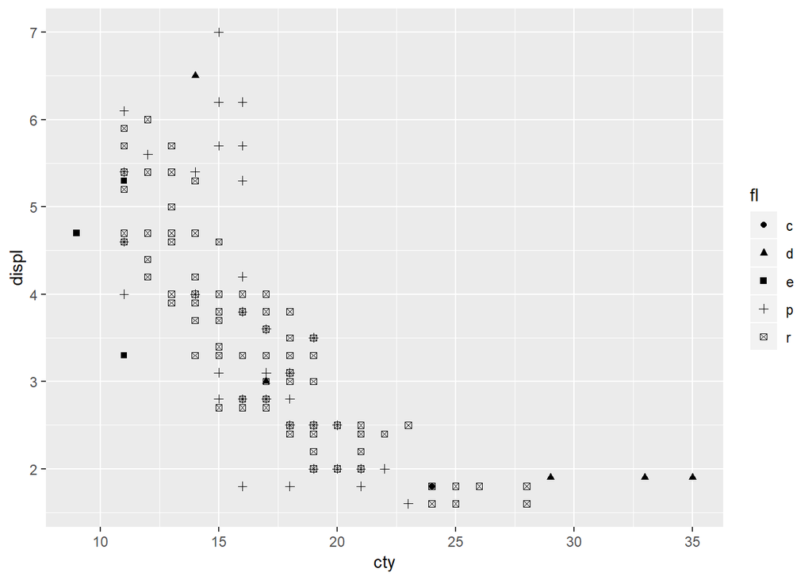

```r
ggplot(mpg,aes(x=cty,y=displ,shape=fl))+geom_point()
```

It display the grap as against continous variable. But shape palette can display a maximum of 6 shapes.

3)What happens if you map the same variable to multiple aesthetics?

What does the stroke aesthetic do? What shapes does it work with? (Hint: use ?geom_point)

What happens if you map an aesthetic to something other than a variable name, like aes(colour = displ < 5)?

multi aesthetics on continous variable

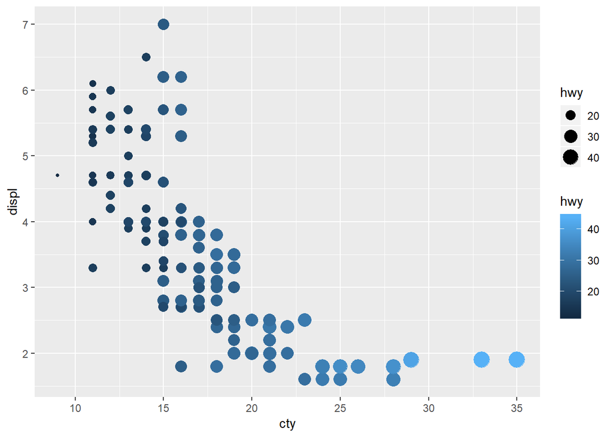

```r
ggplot(mpg,aes(x=cty,y=displ,color=hwy,size=hwy))+geom_point()
```

yes it can be represented with color and size for continous variables.

multi aesthetics on caterogical variables.

```
## Warning: Using size for a discrete variable is not advised.
```

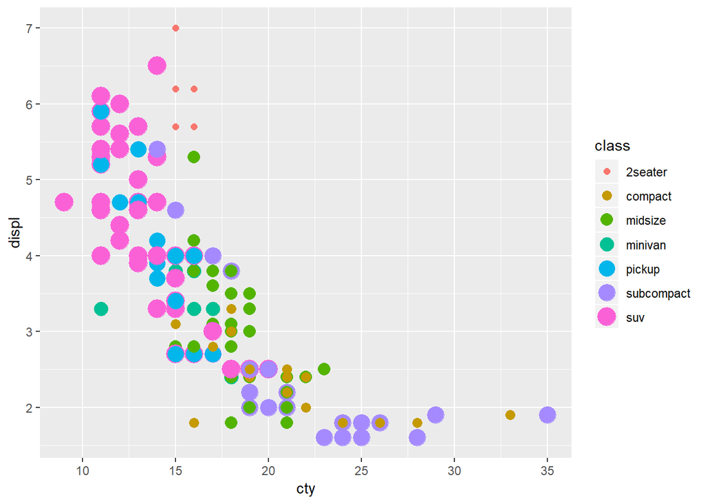

```r
ggplot(mpg,aes(x=cty,y=displ,color=class,size=class))+geom_point()
```

Ans With same categorial variables can be plotted but with warnings.

4)What does the stroke aesthetic do? What shapes does it work with? (Hint: use ?geom_point)

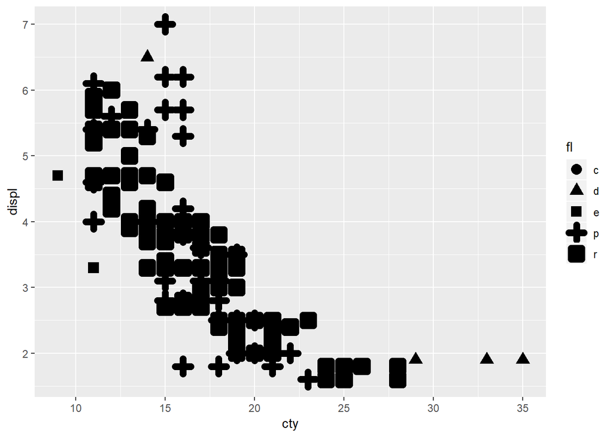

```r
?geom_point

ggplot(mpg,aes(x=cty,y=displ,shape=fl))+geom_point(stroke=4)
```

stroke alters the sizes of shapes

What happens if you map an aesthetic to something other than a variable name, like aes(colour = displ < 5)?

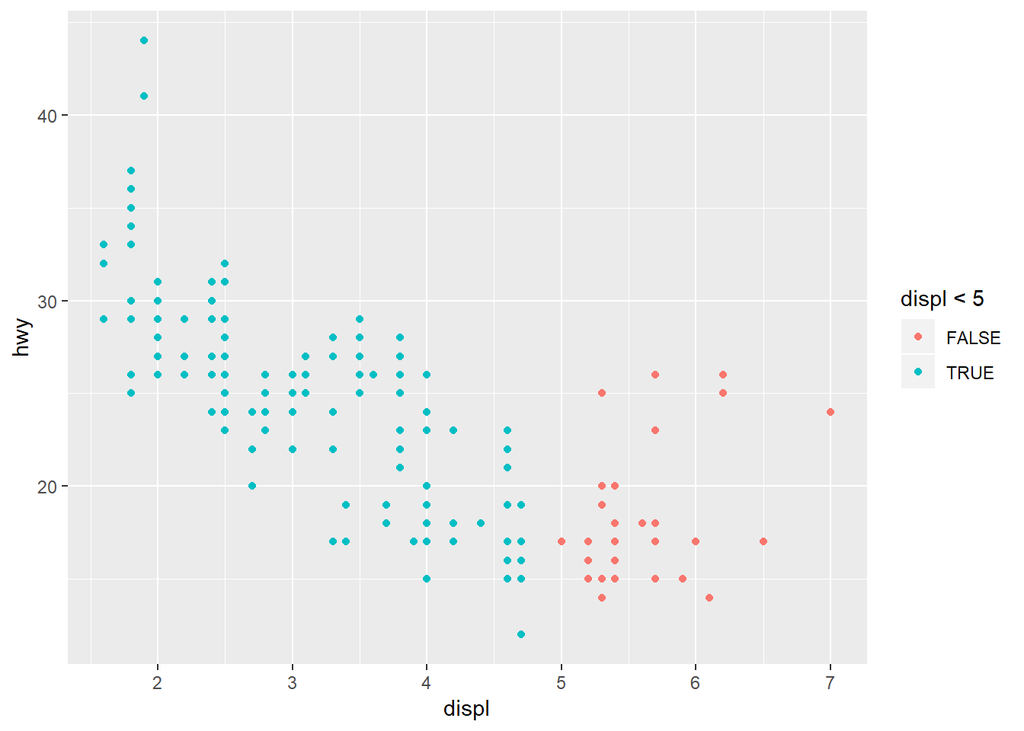

```r
ggplot(mpg,aes(x=displ,y=hwy,color=displ<5))+geom_point()
```

It changes the values into boolean i.e true and false ; true / false depicting different colours each and is ploted to the graph.